# Optimal Treatment Analysis

## Outcome Variable

**Outcome Variable:** haz

## Predictor Variables

**Intervention Variable:** anywast06

**Adjustment Set:**

- arm
- sex
- brthmon
- W_mage
- meducyrs
- hhwealth_quart
- W_nrooms
- month
- W_parity
- delta_W_mage
- delta_meducyrs
- delta_hhwealth_quart
- delta_W_nrooms
- delta_month
- delta_W_parity

## Stratifying Variables

The analysis was stratified on these variable(s):

- agecat
- studyid
- country

## Data Summary

| agecat | studyid | country | anywast06 | n_cell | n |
| --- | --- | --- | --- | --- | --- |
| Birth | ki0047075b-MAL-ED | BANGLADESH | 0 | 177 | 229 |
| Birth | ki0047075b-MAL-ED | BANGLADESH | 1 | 52 | 229 |
| Birth | ki0047075b-MAL-ED | BRAZIL | 0 | 62 | 65 |
| Birth | ki0047075b-MAL-ED | BRAZIL | 1 | 3 | 65 |
| Birth | ki0047075b-MAL-ED | INDIA | 0 | 33 | 47 |
| Birth | ki0047075b-MAL-ED | INDIA | 1 | 14 | 47 |
| Birth | ki0047075b-MAL-ED | NEPAL | 0 | 23 | 27 |
| Birth | ki0047075b-MAL-ED | NEPAL | 1 | 4 | 27 |
| Birth | ki0047075b-MAL-ED | PERU | 0 | 223 | 233 |
| Birth | ki0047075b-MAL-ED | PERU | 1 | 10 | 233 |
| Birth | ki0047075b-MAL-ED | SOUTH AFRICA | 0 | 102 | 122 |
| Birth | ki0047075b-MAL-ED | SOUTH AFRICA | 1 | 20 | 122 |
| Birth | ki0047075b-MAL-ED | TANZANIA, UNITED REPUBLIC OF | 0 | 119 | 124 |
| Birth | ki0047075b-MAL-ED | TANZANIA, UNITED REPUBLIC OF | 1 | 5 | 124 |
| Birth | ki1000108-CMC-V-BCS-2002 | INDIA | 0 | 37 | 92 |
| Birth | ki1000108-CMC-V-BCS-2002 | INDIA | 1 | 55 | 92 |
| Birth | ki1000108-IRC | INDIA | 0 | 164 | 388 |
| Birth | ki1000108-IRC | INDIA | 1 | 224 | 388 |
| Birth | ki1000109-EE | PAKISTAN | 0 | 156 | 240 |
| Birth | ki1000109-EE | PAKISTAN | 1 | 84 | 240 |
| Birth | ki1000109-ResPak | PAKISTAN | 0 | 28 | 42 |
| Birth | ki1000109-ResPak | PAKISTAN | 1 | 14 | 42 |
| Birth | ki1017093b-PROVIDE | BANGLADESH | 0 | 396 | 539 |
| Birth | ki1017093b-PROVIDE | BANGLADESH | 1 | 143 | 539 |
| Birth | ki1101329-Keneba | GAMBIA | 0 | 994 | 1542 |
| Birth | ki1101329-Keneba | GAMBIA | 1 | 548 | 1542 |
| Birth | ki1113344-GMS-Nepal | NEPAL | 0 | 422 | 684 |
| Birth | ki1113344-GMS-Nepal | NEPAL | 1 | 262 | 684 |
| Birth | ki1114097-CMIN | BANGLADESH | 0 | 15 | 20 |
| Birth | ki1114097-CMIN | BANGLADESH | 1 | 5 | 20 |

[output cut: 70 more lines]

The following strata were considered:

- agecat: 24 months, studyid: ki0047075b-MAL-ED, country: BANGLADESH
- agecat: 24 months, studyid: ki0047075b-MAL-ED, country: BRAZIL
- agecat: 24 months, studyid: ki0047075b-MAL-ED, country: INDIA
- agecat: 24 months, studyid: ki0047075b-MAL-ED, country: NEPAL
- agecat: 24 months, studyid: ki0047075b-MAL-ED, country: PERU
- agecat: 24 months, studyid: ki0047075b-MAL-ED, country: SOUTH AFRICA
- agecat: 24 months, studyid: ki0047075b-MAL-ED, country: TANZANIA, UNITED REPUBLIC OF
- agecat: 24 months, studyid: ki1000108-CMC-V-BCS-2002, country: INDIA
- agecat: 24 months, studyid: ki1000108-IRC, country: INDIA
- agecat: 24 months, studyid: ki1000109-EE, country: PAKISTAN
- agecat: 24 months, studyid: ki1017093b-PROVIDE, country: BANGLADESH
- agecat: 24 months, studyid: ki1066203-TanzaniaChild2, country: TANZANIA, UNITED REPUBLIC OF
- agecat: 24 months, studyid: ki1101329-Keneba, country: GAMBIA
- agecat: 24 months, studyid: ki1113344-GMS-Nepal, country: NEPAL
- agecat: 24 months, studyid: ki1114097-CMIN, country: BANGLADESH
- agecat: 24 months, studyid: ki1114097-CONTENT, country: PERU
- agecat: 6 months, studyid: ki0047075b-MAL-ED, country: BANGLADESH
- agecat: 6 months, studyid: ki0047075b-MAL-ED, country: BRAZIL
- agecat: 6 months, studyid: ki0047075b-MAL-ED, country: INDIA
- agecat: 6 months, studyid: ki0047075b-MAL-ED, country: NEPAL
- agecat: 6 months, studyid: ki0047075b-MAL-ED, country: PERU
- agecat: 6 months, studyid: ki0047075b-MAL-ED, country: SOUTH AFRICA
- agecat: 6 months, studyid: ki0047075b-MAL-ED, country: TANZANIA, UNITED REPUBLIC OF
- agecat: 6 months, studyid: ki1000108-CMC-V-BCS-2002, country: INDIA
- agecat: 6 months, studyid: ki1000108-IRC, country: INDIA
- agecat: 6 months, studyid: ki1000109-EE, country: PAKISTAN
- agecat: 6 months, studyid: ki1000109-ResPak, country: PAKISTAN
- agecat: 6 months, studyid: ki1017093b-PROVIDE, country: BANGLADESH
- agecat: 6 months, studyid: ki1066203-TanzaniaChild2, country: TANZANIA, UNITED REPUBLIC OF
- agecat: 6 months, studyid: ki1101329-Keneba, country: GAMBIA
- agecat: 6 months, studyid: ki1112895-Guatemala BSC, country: GUATEMALA
- agecat: 6 months, studyid: ki1113344-GMS-Nepal, country: NEPAL
- agecat: 6 months, studyid: ki1114097-CMIN, country: BANGLADESH
- agecat: 6 months, studyid: ki1114097-CONTENT, country: PERU
- agecat: Birth, studyid: ki0047075b-MAL-ED, country: BANGLADESH
- agecat: Birth, studyid: ki0047075b-MAL-ED, country: BRAZIL
- agecat: Birth, studyid: ki0047075b-MAL-ED, country: INDIA
- agecat: Birth, studyid: ki0047075b-MAL-ED, country: NEPAL
- agecat: Birth, studyid: ki0047075b-MAL-ED, country: PERU
- agecat: Birth, studyid: ki0047075b-MAL-ED, country: SOUTH AFRICA
- agecat: Birth, studyid: ki0047075b-MAL-ED, country: TANZANIA, UNITED REPUBLIC OF
- agecat: Birth, studyid: ki1000108-CMC-V-BCS-2002, country: INDIA
- agecat: Birth, studyid: ki1000108-IRC, country: INDIA
- agecat: Birth, studyid: ki1000109-EE, country: PAKISTAN
- agecat: Birth, studyid: ki1000109-ResPak, country: PAKISTAN
- agecat: Birth, studyid: ki1017093b-PROVIDE, country: BANGLADESH
- agecat: Birth, studyid: ki1101329-Keneba, country: GAMBIA
- agecat: Birth, studyid: ki1113344-GMS-Nepal, country: NEPAL
- agecat: Birth, studyid: ki1114097-CMIN, country: BANGLADESH
- agecat: Birth, studyid: ki1114097-CONTENT, country: PERU

### Dropped Strata

Some strata were dropped due to rare outcomes:

- agecat: Birth, studyid: ki0047075b-MAL-ED, country: BRAZIL
- agecat: Birth, studyid: ki0047075b-MAL-ED, country: NEPAL
- agecat: Birth, studyid: ki1114097-CONTENT, country: PERU
- agecat: 6 months, studyid: ki1114097-CONTENT, country: PERU
- agecat: 24 months, studyid: ki1066203-TanzaniaChild2, country: TANZANIA, UNITED REPUBLIC OF
- agecat: 24 months, studyid: ki1114097-CONTENT, country: PERU

## Methods Detail

We’re interested in the causal parameters $E[Y_a]$ for all values of $a \in \mathcal{A}$. These parameters represent the mean outcome if, possibly contrary to fact, we intervened to set all units to have $A=a$. Under the randomization and positivity assumptions, these are identified by the statistical parameters $\psi_a=E_W[E_{Y|A,W}(Y|A=a,W)]$. In addition, we’re interested in the mean of $Y$, $E[Y]$ under no intervention (the observed mean). We will estimate these parameters by using SuperLearner to fit the relevant likelihood factors – $E_{Y|A,W}(Y|A=a,W)$ and $p(A=a|W)$, and then updating our likelihood fit using a joint TMLE.

For unadjusted analyses ($W=\{\}$), initial likelihoods were estimated using Lrnr_glm to estimate the simple $E(Y|A)$ and Lrnr_mean to estimate $p(A)$. For adjusted analyses, a small library containing Lrnr_glmnet, Lrnr_xgboost, and Lrnr_mean was used.

Having estimated these parameters, we will then use the delta method to estimate relative risks and attributable risks relative to a prespecified baseline level of $A$.

# Results Detail

## Results Plots

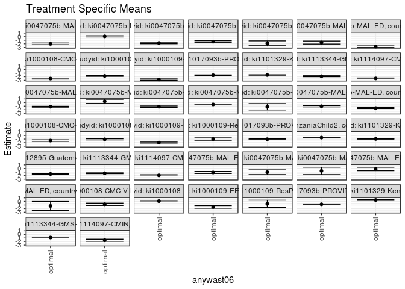

## Results Table

### Parameter: TSM

| agecat | studyid | country | intervention_level | baseline_level | estimate | ci_lower | ci_upper |
| --- | --- | --- | --- | --- | --- | --- | --- |
| Birth | ki0047075b-MAL-ED | BANGLADESH | optimal | observed | -1.1214692 | -1.4187328 | -0.8242057 |
| Birth | ki0047075b-MAL-ED | INDIA | optimal | observed | -1.0442703 | -1.7057273 | -0.3828134 |
| Birth | ki0047075b-MAL-ED | PERU | optimal | observed | -0.6756469 | -1.7080661 | 0.3567722 |
| Birth | ki0047075b-MAL-ED | SOUTH AFRICA | optimal | observed | -0.1506064 | -0.6345332 | 0.3333204 |
| Birth | ki0047075b-MAL-ED | TANZANIA, UNITED REPUBLIC OF | optimal | observed | -1.2517800 | -2.4968593 | -0.0067008 |
| Birth | ki1000108-CMC-V-BCS-2002 | INDIA | optimal | observed | -0.7960943 | -1.1262150 | -0.4659737 |
| Birth | ki1000108-IRC | INDIA | optimal | observed | 0.0878166 | -0.1303574 | 0.3059905 |
| Birth | ki1000109-EE | PAKISTAN | optimal | observed | -1.5353295 | -1.8976320 | -1.1730269 |
| Birth | ki1000109-ResPak | PAKISTAN | optimal | observed | -0.6584722 | -1.6589335 | 0.3419892 |
| Birth | ki1017093b-PROVIDE | BANGLADESH | optimal | observed | -0.7931716 | -0.9020382 | -0.6843051 |
| Birth | ki1101329-Keneba | GAMBIA | optimal | observed | 0.4043574 | 0.2927731 | 0.5159417 |
| Birth | ki1113344-GMS-Nepal | NEPAL | optimal | observed | -0.8773420 | -0.9987698 | -0.7559143 |
| Birth | ki1114097-CMIN | BANGLADESH | optimal | observed | -1.6354575 | -1.9260121 | -1.3449029 |
| 6 months | ki0047075b-MAL-ED | BANGLADESH | optimal | observed | -1.1686061 | -1.2940151 | -1.0431972 |
| 6 months | ki0047075b-MAL-ED | BRAZIL | optimal | observed | 0.3335333 | -0.2386590 | 0.9057257 |
| 6 months | ki0047075b-MAL-ED | INDIA | optimal | observed | -1.1642288 | -1.3836945 | -0.9447630 |
| 6 months | ki0047075b-MAL-ED | NEPAL | optimal | observed | -0.5285365 | -0.6491464 | -0.4079267 |
| 6 months | ki0047075b-MAL-ED | PERU | optimal | observed | -1.1836272 | -2.0776837 | -0.2895707 |
| 6 months | ki0047075b-MAL-ED | SOUTH AFRICA | optimal | observed | -1.0239867 | -1.2175845 | -0.8303890 |
| 6 months | ki0047075b-MAL-ED | TANZANIA, UNITED REPUBLIC OF | optimal | observed | -1.5468907 | -1.6822840 | -1.4114973 |
| 6 months | ki1000108-CMC-V-BCS-2002 | INDIA | optimal | observed | -1.4212474 | -1.6397520 | -1.2027427 |
| 6 months | ki1000108-IRC | INDIA | optimal | observed | -1.0710644 | -1.2475533 | -0.8945756 |
| 6 months | ki1000109-EE | PAKISTAN | optimal | observed | -1.9795601 | -2.1331291 | -1.8259912 |
| 6 months | ki1000109-ResPak | PAKISTAN | optimal | observed | -1.0006535 | -1.3375211 | -0.6637859 |
| 6 months | ki1017093b-PROVIDE | BANGLADESH | optimal | observed | -1.0475323 | -1.1527389 | -0.9423256 |
| 6 months | ki1066203-TanzaniaChild2 | TANZANIA, UNITED REPUBLIC OF | optimal | observed | -0.5914543 | -0.6766897 | -0.5062190 |
| 6 months | ki1101329-Keneba | GAMBIA | optimal | observed | -0.9634583 | -1.0273914 | -0.8995252 |
| 6 months | ki1112895-Guatemala BSC | GUATEMALA | optimal | observed | -1.5453634 | -1.6575415 | -1.4331852 |
| 6 months | ki1113344-GMS-Nepal | NEPAL | optimal | observed | -1.3345681 | -1.4566832 | -1.2124529 |
| 6 months | ki1114097-CMIN | BANGLADESH | optimal | observed | -1.9316650 | -2.1044593 | -1.7588707 |
| 24 months | ki0047075b-MAL-ED | BANGLADESH | optimal | observed | -2.0101572 | -2.2528475 | -1.7674669 |
| 24 months | ki0047075b-MAL-ED | BRAZIL | optimal | observed | 0.0853003 | -0.0922479 | 0.2628485 |
| 24 months | ki0047075b-MAL-ED | INDIA | optimal | observed | -1.7695123 | -1.9927460 | -1.5462787 |
| 24 months | ki0047075b-MAL-ED | NEPAL | optimal | observed | -1.4011005 | -1.6652713 | -1.1369297 |
| 24 months | ki0047075b-MAL-ED | PERU | optimal | observed | -1.8560471 | -2.5257847 | -1.1863096 |
| 24 months | ki0047075b-MAL-ED | SOUTH AFRICA | optimal | observed | -1.6511598 | -2.0695219 | -1.2327976 |
| 24 months | ki0047075b-MAL-ED | TANZANIA, UNITED REPUBLIC OF | optimal | observed | -2.8038962 | -3.0292361 | -2.5785563 |
| 24 months | ki1000108-CMC-V-BCS-2002 | INDIA | optimal | observed | -2.5204483 | -2.6654066 | -2.3754900 |
| 24 months | ki1000108-IRC | INDIA | optimal | observed | -1.7735247 | -1.9048134 | -1.6422359 |
| 24 months | ki1000109-EE | PAKISTAN | optimal | observed | -2.7920554 | -2.9818497 | -2.6022611 |
| 24 months | ki1017093b-PROVIDE | BANGLADESH | optimal | observed | -1.5874878 | -1.6869002 | -1.4880755 |
| 24 months | ki1101329-Keneba | GAMBIA | optimal | observed | -1.5224857 | -1.5908221 | -1.4541492 |
| 24 months | ki1113344-GMS-Nepal | NEPAL | optimal | observed | -1.8633121 | -1.9990238 | -1.7276004 |
| 24 months | ki1114097-CMIN | BANGLADESH | optimal | observed | -2.4843067 | -2.6223564 | -2.3462571 |

### Parameter: E(Y)

| agecat | studyid | country | intervention_level | baseline_level | estimate | ci_lower | ci_upper |
| --- | --- | --- | --- | --- | --- | --- | --- |
| Birth | ki0047075b-MAL-ED | BANGLADESH | observed | observed | -1.1041048 | -1.2383048 | -0.9699048 |
| Birth | ki0047075b-MAL-ED | INDIA | observed | observed | -1.2036170 | -1.4976814 | -0.9095527 |
| Birth | ki0047075b-MAL-ED | PERU | observed | observed | -0.8827897 | -1.0001058 | -0.7654736 |
| Birth | ki0047075b-MAL-ED | SOUTH AFRICA | observed | observed | -0.5877869 | -0.7622273 | -0.4133464 |
| Birth | ki0047075b-MAL-ED | TANZANIA, UNITED REPUBLIC OF | observed | observed | -1.1369355 | -1.3453337 | -0.9285373 |
| Birth | ki1000108-CMC-V-BCS-2002 | INDIA | observed | observed | -0.9611957 | -1.1776967 | -0.7446946 |
| Birth | ki1000108-IRC | INDIA | observed | observed | -0.3080412 | -0.4687931 | -0.1472894 |
| Birth | ki1000109-EE | PAKISTAN | observed | observed | -1.8608750 | -2.0482045 | -1.6735455 |
| Birth | ki1000109-ResPak | PAKISTAN | observed | observed | -0.9800000 | -1.4086438 | -0.5513562 |
| Birth | ki1017093b-PROVIDE | BANGLADESH | observed | observed | -0.8851020 | -0.9601332 | -0.8100709 |
| Birth | ki1101329-Keneba | GAMBIA | observed | observed | 0.0325486 | -0.0310420 | 0.0961393 |
| Birth | ki1113344-GMS-Nepal | NEPAL | observed | observed | -1.0454532 | -1.1235003 | -0.9674062 |
| Birth | ki1114097-CMIN | BANGLADESH | observed | observed | -1.2030000 | -1.6953191 | -0.7106809 |
| 6 months | ki0047075b-MAL-ED | BANGLADESH | observed | observed | -1.2054910 | -1.3228953 | -1.0880867 |
| 6 months | ki0047075b-MAL-ED | BRAZIL | observed | observed | 0.0510207 | -0.0930194 | 0.1950608 |
| 6 months | ki0047075b-MAL-ED | INDIA | observed | observed | -1.2113701 | -1.3298485 | -1.0928916 |
| 6 months | ki0047075b-MAL-ED | NEPAL | observed | observed | -0.5610593 | -0.6737915 | -0.4483272 |
| 6 months | ki0047075b-MAL-ED | PERU | observed | observed | -1.3280952 | -1.4363364 | -1.2198541 |
| 6 months | ki0047075b-MAL-ED | SOUTH AFRICA | observed | observed | -1.0639173 | -1.1916078 | -0.9362269 |
| 6 months | ki0047075b-MAL-ED | TANZANIA, UNITED REPUBLIC OF | observed | observed | -1.3687449 | -1.4907629 | -1.2467270 |
| 6 months | ki1000108-CMC-V-BCS-2002 | INDIA | observed | observed | -1.4241872 | -1.5668135 | -1.2815609 |
| 6 months | ki1000108-IRC | INDIA | observed | observed | -1.2344062 | -1.3658524 | -1.1029600 |
| 6 months | ki1000109-EE | PAKISTAN | observed | observed | -2.0835567 | -2.2027557 | -1.9643578 |
| 6 months | ki1000109-ResPak | PAKISTAN | observed | observed | -1.4314086 | -1.6374838 | -1.2253335 |
| 6 months | ki1017093b-PROVIDE | BANGLADESH | observed | observed | -1.0916915 | -1.1661176 | -1.0172654 |
| 6 months | ki1066203-TanzaniaChild2 | TANZANIA, UNITED REPUBLIC OF | observed | observed | -0.5434389 | -0.5924056 | -0.4944722 |
| 6 months | ki1101329-Keneba | GAMBIA | observed | observed | -0.9116762 | -0.9588660 | -0.8644864 |
| 6 months | ki1112895-Guatemala BSC | GUATEMALA | observed | observed | -1.5785476 | -1.6926664 | -1.4644288 |
| 6 months | ki1113344-GMS-Nepal | NEPAL | observed | observed | -1.3508392 | -1.4290633 | -1.2726152 |
| 6 months | ki1114097-CMIN | BANGLADESH | observed | observed | -1.7844376 | -1.9222926 | -1.6465825 |
| 24 months | ki0047075b-MAL-ED | BANGLADESH | observed | observed | -1.9789151 | -2.1055330 | -1.8522972 |
| 24 months | ki0047075b-MAL-ED | BRAZIL | observed | observed | 0.0071006 | -0.1615817 | 0.1757828 |
| 24 months | ki0047075b-MAL-ED | INDIA | observed | observed | -1.8848458 | -2.0096941 | -1.7599975 |
| 24 months | ki0047075b-MAL-ED | NEPAL | observed | observed | -1.3118640 | -1.4315132 | -1.1922149 |
| 24 months | ki0047075b-MAL-ED | PERU | observed | observed | -1.7544776 | -1.8753255 | -1.6336298 |
| 24 months | ki0047075b-MAL-ED | SOUTH AFRICA | observed | observed | -1.6491807 | -1.7842885 | -1.5140729 |
| 24 months | ki0047075b-MAL-ED | TANZANIA, UNITED REPUBLIC OF | observed | observed | -2.6451636 | -2.7802323 | -2.5100948 |
| 24 months | ki1000108-CMC-V-BCS-2002 | INDIA | observed | observed | -2.5489071 | -2.6476125 | -2.4502017 |
| 24 months | ki1000108-IRC | INDIA | observed | observed | -1.7987775 | -1.8923914 | -1.7051636 |
| 24 months | ki1000109-EE | PAKISTAN | observed | observed | -2.6699900 | -2.8138051 | -2.5261749 |
| 24 months | ki1017093b-PROVIDE | BANGLADESH | observed | observed | -1.6024221 | -1.6857420 | -1.5191023 |
| 24 months | ki1101329-Keneba | GAMBIA | observed | observed | -1.5774758 | -1.6295950 | -1.5253566 |
| 24 months | ki1113344-GMS-Nepal | NEPAL | observed | observed | -1.8874180 | -1.9728588 | -1.8019773 |
| 24 months | ki1114097-CMIN | BANGLADESH | observed | observed | -2.5109504 | -2.6361514 | -2.3857494 |

### Parameter: PAR

| agecat | studyid | country | intervention_level | baseline_level | estimate | ci_lower | ci_upper |
| --- | --- | --- | --- | --- | --- | --- | --- |
| Birth | ki0047075b-MAL-ED | BANGLADESH | optimal | observed | 0.0173644 | -0.2294056 | 0.2641344 |
| Birth | ki0047075b-MAL-ED | INDIA | optimal | observed | -0.1593467 | -0.6912721 | 0.3725787 |
| Birth | ki0047075b-MAL-ED | PERU | optimal | observed | -0.2071428 | -1.2122199 | 0.7979343 |
| Birth | ki0047075b-MAL-ED | SOUTH AFRICA | optimal | observed | -0.4371805 | -0.8741705 | -0.0001904 |
| Birth | ki0047075b-MAL-ED | TANZANIA, UNITED REPUBLIC OF | optimal | observed | 0.1148445 | -1.1113471 | 1.3410361 |
| Birth | ki1000108-CMC-V-BCS-2002 | INDIA | optimal | observed | -0.1651013 | -0.4323777 | 0.1021750 |
| Birth | ki1000108-IRC | INDIA | optimal | observed | -0.3958578 | -0.5332229 | -0.2584927 |
| Birth | ki1000109-EE | PAKISTAN | optimal | observed | -0.3255455 | -0.6028559 | -0.0482352 |
| Birth | ki1000109-ResPak | PAKISTAN | optimal | observed | -0.3215278 | -1.1058362 | 0.4627806 |
| Birth | ki1017093b-PROVIDE | BANGLADESH | optimal | observed | -0.0919304 | -0.1740075 | -0.0098533 |
| Birth | ki1101329-Keneba | GAMBIA | optimal | observed | -0.3718088 | -0.4596912 | -0.2839263 |
| Birth | ki1113344-GMS-Nepal | NEPAL | optimal | observed | -0.1681112 | -0.2659313 | -0.0702910 |
| Birth | ki1114097-CMIN | BANGLADESH | optimal | observed | 0.4324575 | -0.0997459 | 0.9646609 |
| 6 months | ki0047075b-MAL-ED | BANGLADESH | optimal | observed | -0.0368849 | -0.1118693 | 0.0380995 |
| 6 months | ki0047075b-MAL-ED | BRAZIL | optimal | observed | -0.2825126 | -0.8318490 | 0.2668238 |
| 6 months | ki0047075b-MAL-ED | INDIA | optimal | observed | -0.0471413 | -0.2235887 | 0.1293061 |
| 6 months | ki0047075b-MAL-ED | NEPAL | optimal | observed | -0.0325228 | -0.0972760 | 0.0322304 |
| 6 months | ki0047075b-MAL-ED | PERU | optimal | observed | -0.1444681 | -1.0202357 | 0.7312996 |
| 6 months | ki0047075b-MAL-ED | SOUTH AFRICA | optimal | observed | -0.0399306 | -0.2192483 | 0.1393870 |
| 6 months | ki0047075b-MAL-ED | TANZANIA, UNITED REPUBLIC OF | optimal | observed | 0.1781457 | 0.0901036 | 0.2661878 |
| 6 months | ki1000108-CMC-V-BCS-2002 | INDIA | optimal | observed | -0.0029399 | -0.1473150 | 0.1414353 |
| 6 months | ki1000108-IRC | INDIA | optimal | observed | -0.1633418 | -0.2786597 | -0.0480239 |
| 6 months | ki1000109-EE | PAKISTAN | optimal | observed | -0.1039966 | -0.2066536 | -0.0013396 |
| 6 months | ki1000109-ResPak | PAKISTAN | optimal | observed | -0.4307551 | -0.6866921 | -0.1748182 |
| 6 months | ki1017093b-PROVIDE | BANGLADESH | optimal | observed | -0.0441592 | -0.1162092 | 0.0278907 |
| 6 months | ki1066203-TanzaniaChild2 | TANZANIA, UNITED REPUBLIC OF | optimal | observed | 0.0480155 | -0.0202771 | 0.1163080 |
| 6 months | ki1101329-Keneba | GAMBIA | optimal | observed | 0.0517821 | 0.0058401 | 0.0977242 |
| 6 months | ki1112895-Guatemala BSC | GUATEMALA | optimal | observed | -0.0331843 | -0.0834927 | 0.0171242 |
| 6 months | ki1113344-GMS-Nepal | NEPAL | optimal | observed | -0.0162712 | -0.1053170 | 0.0727746 |
| 6 months | ki1114097-CMIN | BANGLADESH | optimal | observed | 0.1472274 | 0.0402058 | 0.2542490 |
| 24 months | ki0047075b-MAL-ED | BANGLADESH | optimal | observed | 0.0312421 | -0.1609163 | 0.2234004 |
| 24 months | ki0047075b-MAL-ED | BRAZIL | optimal | observed | -0.0781997 | -0.1867392 | 0.0303398 |
| 24 months | ki0047075b-MAL-ED | INDIA | optimal | observed | -0.1153335 | -0.2953944 | 0.0647274 |
| 24 months | ki0047075b-MAL-ED | NEPAL | optimal | observed | 0.0892365 | -0.1321337 | 0.3106067 |
| 24 months | ki0047075b-MAL-ED | PERU | optimal | observed | 0.1015695 | -0.5526731 | 0.7558121 |
| 24 months | ki0047075b-MAL-ED | SOUTH AFRICA | optimal | observed | 0.0019791 | -0.3809886 | 0.3849469 |
| 24 months | ki0047075b-MAL-ED | TANZANIA, UNITED REPUBLIC OF | optimal | observed | 0.1587327 | -0.0239053 | 0.3413707 |
| 24 months | ki1000108-CMC-V-BCS-2002 | INDIA | optimal | observed | -0.0284588 | -0.1287945 | 0.0718769 |
| 24 months | ki1000108-IRC | INDIA | optimal | observed | -0.0252528 | -0.1076260 | 0.0571203 |
| 24 months | ki1000109-EE | PAKISTAN | optimal | observed | 0.1220654 | -0.0093201 | 0.2534509 |
| 24 months | ki1017093b-PROVIDE | BANGLADESH | optimal | observed | -0.0149343 | -0.0583891 | 0.0285204 |
| 24 months | ki1101329-Keneba | GAMBIA | optimal | observed | -0.0549901 | -0.1024391 | -0.0075411 |
| 24 months | ki1113344-GMS-Nepal | NEPAL | optimal | observed | -0.0241059 | -0.1215417 | 0.0733298 |
| 24 months | ki1114097-CMIN | BANGLADESH | optimal | observed | -0.0266437 | -0.0834639 | 0.0301765 |